# HWPreBootCamp

NehaBora

June 11, 2017

Mother Jones magazine has tracked data on every mass shooting in the U.S. from 1982 to present.

```r
MJ <- read.csv("https://www.macalester.edu/~ajohns24/data/MassShootings.csv")
MJ$Date <- as.Date(MJ$Day, format="%m/%d/%y")
```

1a)Each row represent a case. There are 82 cases in this data set with 23 variables describing each case.

```r
dim(MJ)
```

```
## [1] 82 23
```

1b) Summarize the number of cases in MJ. Examine the first cases of MJ.

```r
head(MJ)
```

```
##                            Event                   Location      State
## 1         Dallas police shooting              Dallas, Texas      texas
## 2     Orlando nightclub massacre           Orlando, Florida    florida
## 3 Excel Industries mass shooting            Hesston, Kansas     kansas
## 4       Kalamazoo shooting spree Kalamazoo County, Michigan   michigan
## 5   San Bernardino mass shooting San Bernardino, California california
## 6      Planned Parenthood clinic Colorado Springs, Colorado   colorado
##   StateColor      Day Year
## 1        red 07/07/16 2016
## 2     purple 06/12/16 2016
## 3        red 02/25/16 2016
## 4       blue 02/20/16 2016
## 5       blue 12/02/15 2015
## 6     purple 11/27/15 2015
##                                                                                                                                                                                                                                                                                                          …
```

[output cut: 62 more lines]

List out names of all variables in MJ

```r
colnames(MJ)
```

```
##  [1] "Event"           "Location"        "State"
##  [4] "StateColor"      "Day"             "Year"
##  [7] "Description"     "Age"             "Fatalities"
## [10] "Wounded"         "TotalVictims"    "Venue"
## [13] "MentalIllness"   "MentalHealth"    "WeaponsLegal"
## [16] "WeaponsObtained" "WeaponType"      "Race"
## [19] "Sex"             "Source"          "Type"
## [22] "X"               "Date"
```

### 2. Cases by Mental Illness of the perpetrator.

1. Category labels used for the mental illness variable

```r
levels(MJ$MentalIllness)
```

```
## [1] "No"      "Pending" "Unclear" "Yes"
```

2. The number of cases that fall into each mental illness category.

```r
table(MJ$MentalIllness)
```

```
##
##      No Pending Unclear     Yes
##      17       2      18      45
```

3. Investigate the prevalence of mental illness among perpetrators of mass shootings.

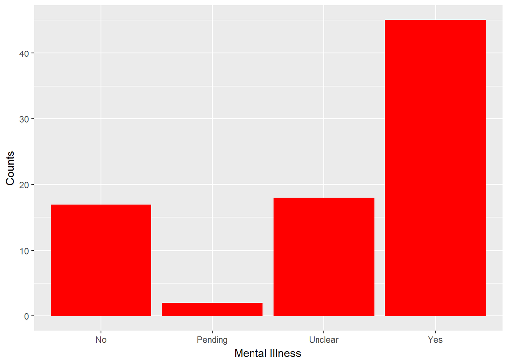

```r
library(ggplot2)
ggplot(MJ,aes(x = MentalIllness)) + geom_bar(fill = 'red') + labs(x = 'Mental Illness', y = 'Counts')
```

4. Summarize your findings about mental illness. We can see that 54% of all the reported murders were committed by perpetrators suffering from mental illness.

### 3. Ages of mass shooting perpetrators.

1. Boxplot

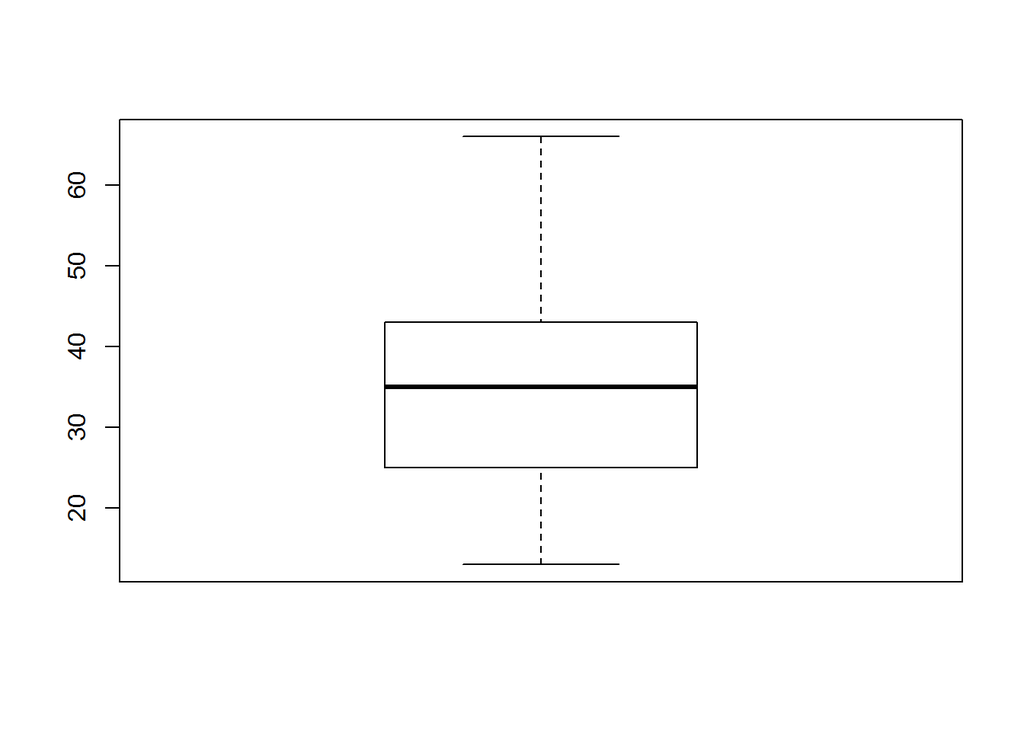

```r
boxplot(MJ$Age)
```

2. Histogram
3. Binwidth = 0.5 years

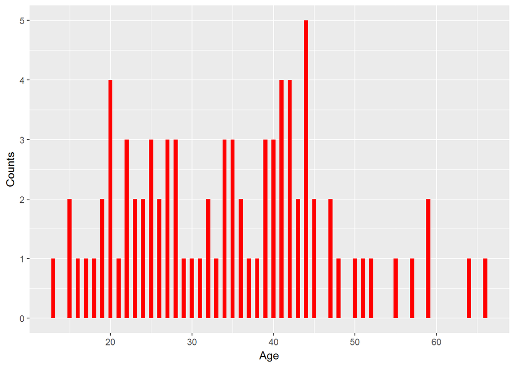

```r
ggplot(MJ,aes(x = Age)) + geom_histogram(fill = 'red', binwidth = 0.5) + labs(x = 'Age', y = 'Counts')
```

b. binwidth = 50 years

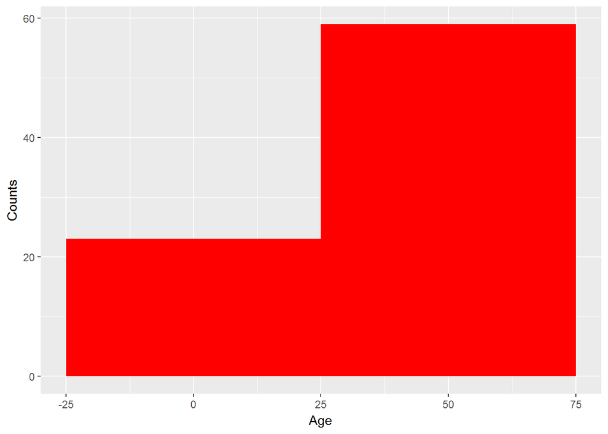

```r
ggplot(MJ,aes(x = Age)) + geom_histogram(fill = 'red', binwidth = 50) + labs(x = 'Age', y = 'Counts')
```

c. We can see the binwidth = 0.5 years it too small and binwidth = 50 years is too big. Neither of the bin sizes capture the trend in the data.

4. Density plot

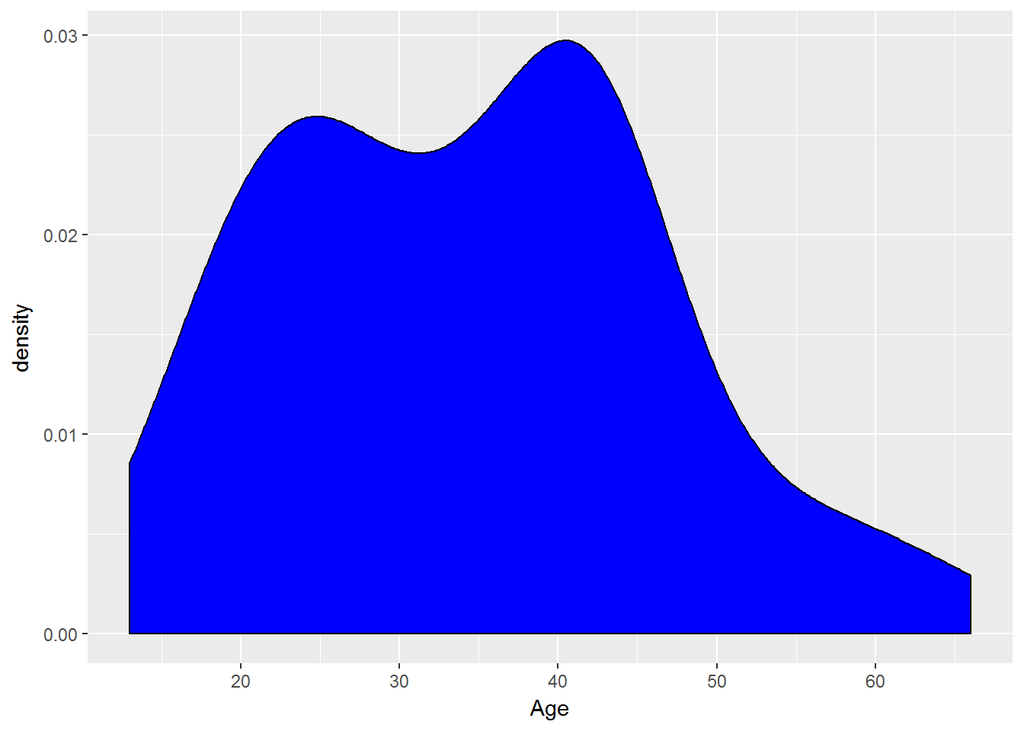

```r
ggplot(MJ,aes(x = Age)) + geom_density(fill = 'blue') + labs(x = 'Age')
```

### 4 Numerical Summaries

Unit: years

```r
mean(MJ$Age)   # Unit years
```

```
## [1] 34.70732
```

```r
median(MJ$Age)  # Unit years
```

```
## [1] 35
```

```r
var(MJ$Age)    # Unit years^2
```

```
## [1] 149.0738
```

```r
sd(MJ$Age)     # Unit years
```

```
## [1] 12.20958
```

```r
# approximate the range of the middle 95% of ages.
mean(MJ$Age) - 2*sd(MJ$Age)
```

```
## [1] 10.28816
```

```r
mean(MJ$Age) + 2*sd(MJ$Age)
```

```
## [1] 59.12647
```

```r
# Calculate the exact range of the middle 95% of ages
quantile(MJ$Age, c(0.025,0.975))
```

```
##   2.5%  97.5%
## 15.025 59.000
```

The approximate values are not close to actual values because the distribution isn’t normally distributed.

### 5

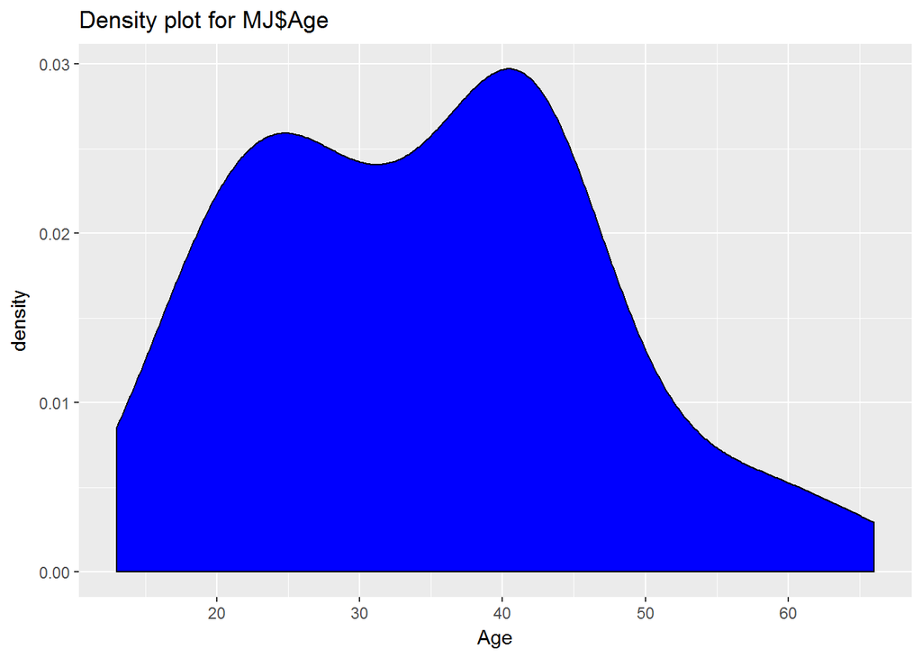

```r
ggplot(MJ,aes(x = Age)) + geom_density(fill = 'blue') + labs(x = 'Age') +ggtitle('Density plot for MJ$Age')
```

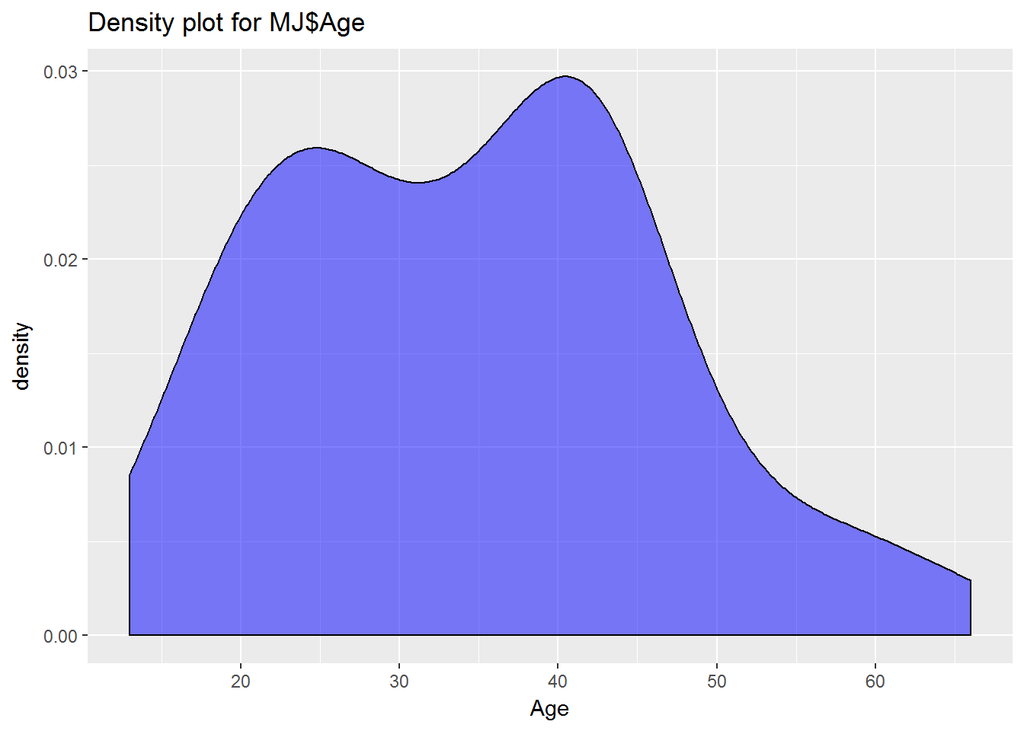

```r
ggplot(MJ,aes(x = Age)) + geom_density(fill = 'blue', alpha = 0.5) + labs(x = 'Age') +ggtitle('Density plot for MJ$Age')
```

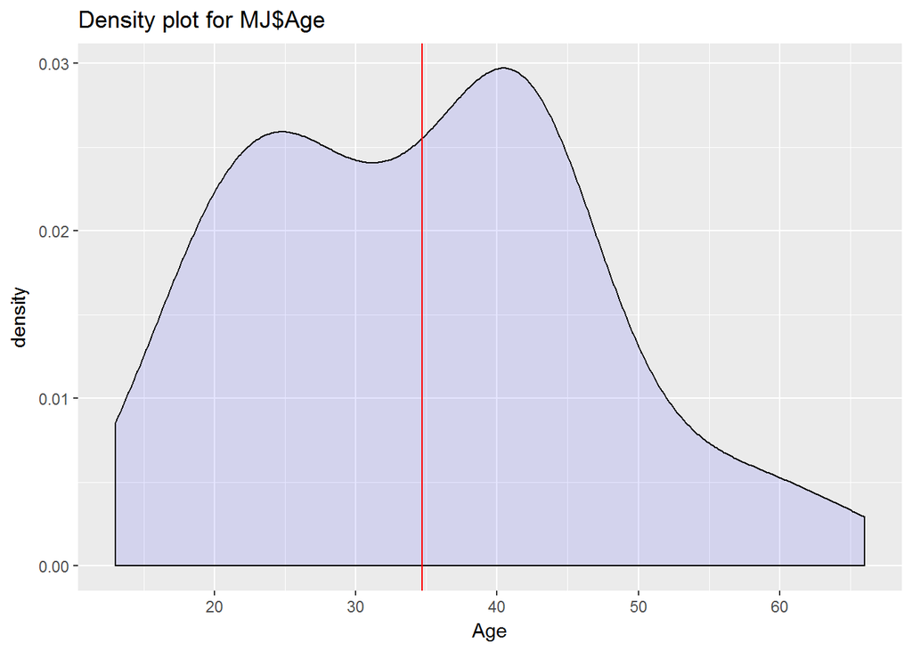

```r
ggplot(MJ,aes(x = Age)) + geom_density(fill = 'blue', alpha = 0.1) + labs(x = 'Age') +ggtitle('Density plot for MJ$Age') + geom_vline(xintercept=mean(MJ$Age), color="red")
```

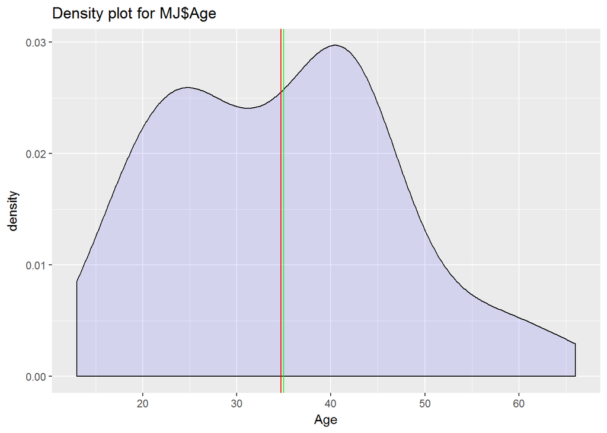

```r
ggplot(MJ,aes(x = Age)) + geom_density(fill = 'blue', alpha = 0.1) + labs(x = 'Age') +ggtitle('Density plot for MJ$Age') + geom_vline(xintercept=mean(MJ$Age), color="red") + geom_vline(xintercept=median(MJ$Age), color="green")
```

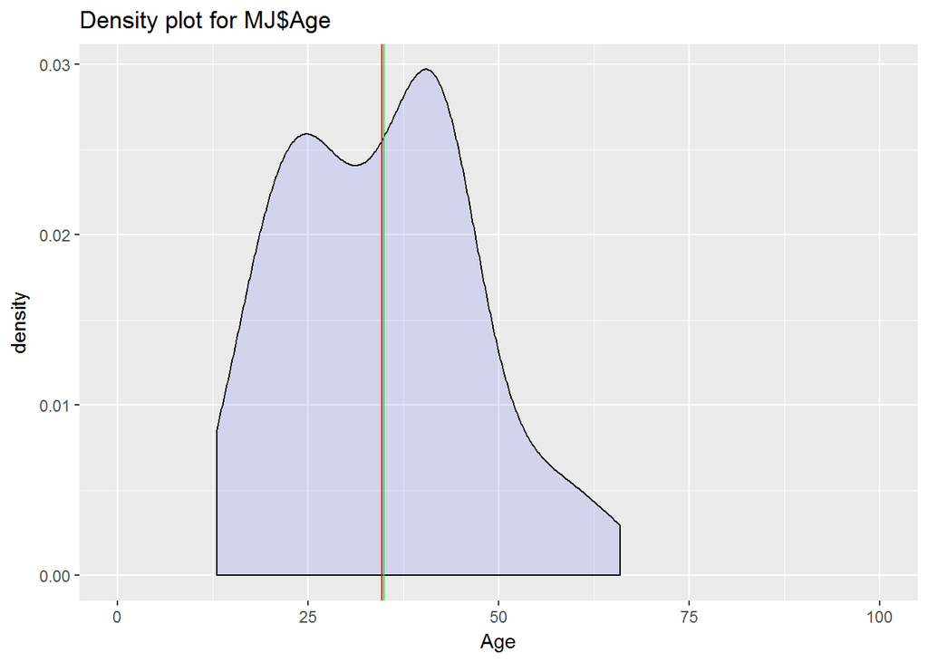

```r
ggplot(MJ,aes(x = Age)) + geom_density(fill = 'blue', alpha = 0.1) + labs(x = 'Age') +ggtitle('Density plot for MJ$Age') + geom_vline(xintercept=mean(MJ$Age), color="red") + geom_vline(xintercept=median(MJ$Age), color="green") + coord_cartesian(xlim = c(0, 100))
```